# molly10_OriginalHomeworkCode_02

Yinuo Mao

2025-02-07

Every Saturday morning, a primatologist records titi monkey calls within a 2-hour window. We assume the number of calls follows a Poisson distribution with a mean of 15 calls per session. The goal is to compute probabilities for specific counts, plot the probability mass function (PMF), and simulate 2 years of observations.

# 1. What is the probability that she will hear more than 8 calls during any given session?

```r
# Set seed to ensure getting the same random results every time
set.seed(1)

# Generate random call counts using normal distribution
call_counts <- round(rnorm(10000, 15, 4))

# Ensure values are non-negative
call_counts[call_counts < 0] <- 0

#check the outcome
summary(call_counts)
```

```
##    Min. 1st Qu.  Median    Mean 3rd Qu.    Max.
##    0.00   12.00   15.00   14.97   18.00   30.00
```

```r
# Calculate the probability using mean() function
prob_more_than_8 <- mean(call_counts > 8)

# Print result
prob_more_than_8
```

```
## [1] 0.9441
```

Claire: I like how you solved this! My only worry is that a Poisson distribution isn’t a normal distribution, so assuming a normal dist might not be accurate? I am also curious where your sd value of 4 came from. Using a ppois() function may work better!

# 2. What is the probability that she will hear no calls in a session?

```r
# Calculate the probability of hearing 0 calls
prob_zero_calls <- mean(call_counts == 0)

# Print result
prob_zero_calls
```

```
## [1] 1e-04
```

Claire: Simple and elegant! I am curious what the mean() function is doing here

# 3. What is the probability that she will hear exactly 3 calls in a session?

```r
# Calculate the probability of hearing exactly 3 calls
prob_three_calls <- mean(call_counts == 3)

# Print result
prob_three_calls
```

```
## [1] 0.0017
```

Claire: same as the comment on the last question

# 4. Plot the relevant Poisson mass function over the values in range 0 ≤ x ≤ 30.

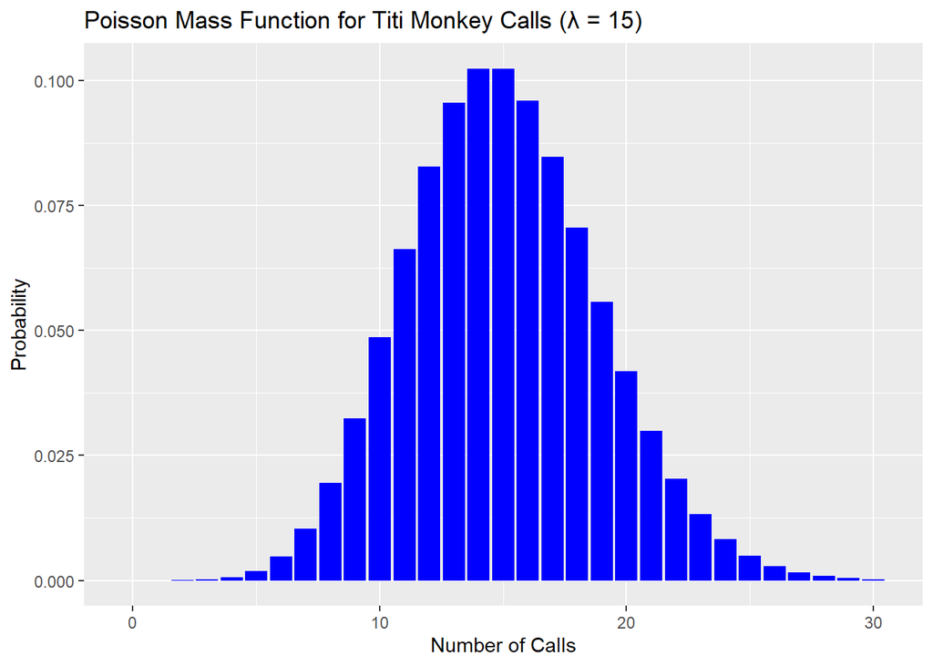

```r
library(ggplot2)

# Define the range of values for x (number of calls)
x_values <- 0:30

# Calculate the Poisson probabilities
poisson_probs <- dpois(x_values, lambda = 15)

# Create the Poisson mass function plot
ggplot(data.frame(x_values, poisson_probs), aes(x = x_values, y = poisson_probs)) +
  geom_col(fill = "blue") +
  # Using geom_col() instead of geom_bar(stat = "identity")
  labs(title = "Poisson Mass Function for Titi Monkey Calls (λ = 15)",
       x = "Number of Calls",
       y = "Probability")
```

Claire: this code is so pretty and neatly laid out, and everything makes sense. I still haven’t gotten the hang of ggplot, so this is super helpful!

# 5.Simulate 104 results from this distribution (i.e., 2 years of Saturday monitoring sessions).

```r
# Set seed
set.seed(2)

# Simulate 104 observations manually
simulated_calls <- round(rnorm(104, 15, 4))

# Display summary of the simulated data
summary(simulated_calls)
```

```
##    Min. 1st Qu.  Median    Mean 3rd Qu.    Max.
##    5.00   12.00   14.00   14.88   18.25   23.00
```

Claire: this makes sense, but I have the same concern as before - I’m not sure whether a normal distribution will accurately match up to your Poisson mass function from the last question. Other than that, good job!

# 6. Plot the simulated results using hist() and use xlim() to set the horizontal limits to be from 0 to 30. How does your histogram compare to the shape of the probability mass function you plotted above?

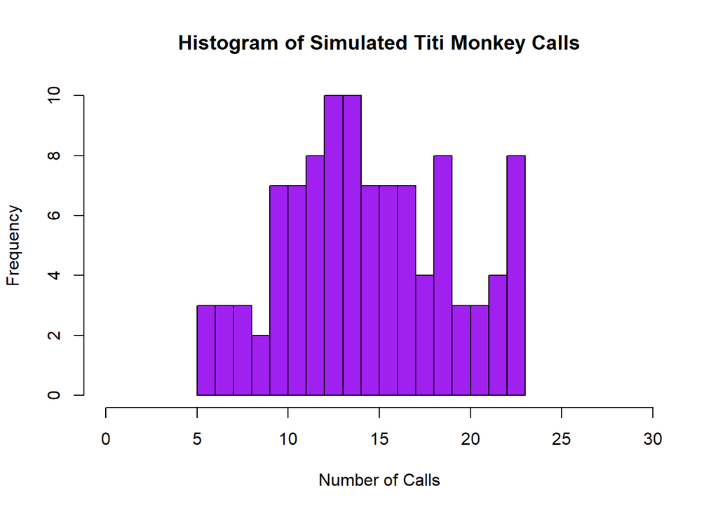

```r
# Plot histogram of simulated calls
hist(simulated_calls, breaks = 15, col = "purple",
     main = "Histogram of Simulated Titi Monkey Calls",
     xlab = "Number of Calls", ylab = "Frequency",
     xlim = c(0, 30))
```

### The histogram of the simulated data closely follows the shape of the Poisson mass function. Both distributions are centered around 15 calls, with a similar spread. However, the histogram has some random variation due to the limited number of simulations, whereas the Poisson mass function represents the theoretical probabilities for an infinite number of observations.